# Klientide segmenteerimine

## Ettevalmistused

Kui soovid koolitust oma arvutiga kaasa teha, siis esmalt paigalda Rstudios järgmised paketid. Vaikimisi seadistustega laetakse need sulle alla ja paigaldatakse automaatselt. Kuna mitmed paketid kasutavad veel omakorda lisapakette, siis võib juhtuda, et sinu arvutisse paigaldatakse palju rohkem pakette kui allolevas koodis kirjas.

```r
install.packages('readxl')
install.packages('dplyr')
install.packages('corrplot')

# Ja laeme paketid töömällu järgmiselt
library(readxl)
library(dplyr)
library(corrplot)
```

## Sissejuhatus

Klientide segmenteerimiseks (või ükskõik milliste andmete lahterdamiseks) kasutame k-keskmiste meetodit (*k-means*). Käime läbi järgmised etapid:

- Andmetega tutvumine
- Andmete puhastamine
- Andmete rikastamine
- Uute andmete eraldamise, agregeerime
- Teostame segmenteerimise
- Analüüsime tulemusi

Näidis analüüsi tegemiseks kasutame vabalt kättesaadavat andmestikku [UCI Machine Learning Repository](https://archive.ics.uci.edu/ml/datasets/online+retail#) veebilehelt, mis on omakorda saanud andmed [Chen, Sain & Guo (2012)](https://link.springer.com/article/10.1057/dbm.2012.17) artiklist.

Andmestikus on Suurbritannias registreeritud veebipoe tehinguandmed vahemikus 1. detsember 2010 - 9. detsember 2011. Veebipoes müüakse enamasti igasugusteks puhkudeks kingitusi ja paljud veebipoe kliendid on jae- või hulgimüüjad. Veebipood tegutseb rahvusvaheliselt aga suur enamus klientuurist on pärit Suurbritanniast.

Andmestiku saate sisse laadida järgmise käsu abil andes ette faili asukoha:

```r
# NB! pead ise määrama faili täpse asukoha failipuus või töökaustas
jaemyyk <- read_excel("../data/jaemyyk.xlsx",
     col_types = c("text", "text", "text",
          "numeric", "date", "numeric", "text",
          "text"))
```

Või lihtsam variant lugeda sisse URLi kaudu (nõuab aga teist paketti):

```r
# NB! peab teadma faili URLi
install.packages('httr')
library(httr)

url = "https://github.com/Rkursus/andmeanalyytik/raw/master/data/jaemyyk.xlsx"
GET(url, write_disk(file <- tempfile(fileext = ".xlsx")))
jaemyyk <- read_excel(file,
     col_types = c("text", "text", "text",
          "numeric", "date", "numeric", "text",
          "text"))
```

## Andmeväljad ja andmestikuga tutvumine

Andmestikuga kaasa tulnud tunnuste kirjeldused on järgmised:

- `arve_nr` - Arve number. Nominaalne tunnus, 6-kohaline arv, mis on iga tehingu puhul unikaalne. Kui kood algab ‘c’ tähega, siis indikeerib see tühistatud tehingut.
- `kood` - Toote või kauba kood. Nominaalne tunnus, 5-kohaline unikaalne number iga toote kohta.
- `kirjeldus` - Toote või kauba kirjeldus. Nominaalne tunnus.
- `kogus` - Iga toote või kauba kogus, mis osteti käesoleval tehingul. Numbriline tunnus.
- `ostu_kp` - Tehingu toimumise kuupäev ja kellaaeg.
- `yhiku_hind` - Toote või kauba ühiku hind. Numbriline, valuuta GBP.
- `kliendi_id` - Unikaalne kliendi ID. Nominaalne tunnus, 5-kohaline number.
- `riik` - riigi nimi. Nominaalne tunnus, riik, kus klient resideerub.

Veendumaks, et tõepoolest on kõik tunnused olemas ning uurimaks andmete sisu, siis käivita järgmised käsud. Mida teevad käsud `head()`, `str()` ja `summary()`?

```r
head(jaemyyk)
```

```
## # A tibble: 6 × 8
##   arve_nr kood   kirjeldus       kogus ostu_kp             yhiku…¹ klien…² riik
##   <chr>   <chr>  <chr>           <dbl> <dttm>                <dbl> <chr>   <chr>
## 1 536365  85123A WHITE HANGING …     6 2010-12-01 08:26:00    2.55 17850   Unit…
## 2 536365  71053  WHITE METAL LA…     6 2010-12-01 08:26:00    3.39 17850   Unit…
## 3 536365  84406B CREAM CUPID HE…     8 2010-12-01 08:26:00    2.75 17850   Unit…
## 4 536365  84029G KNITTED UNION …     6 2010-12-01 08:26:00    3.39 17850   Unit…
## 5 536365  84029E RED WOOLLY HOT…     6 2010-12-01 08:26:00    3.39 17850   Unit…
## 6 536365  22752  SET 7 BABUSHKA…     2 2010-12-01 08:26:00    7.65 17850   Unit…
## # … with abbreviated variable names ¹yhiku_hind, ²kliendi_id
```

```r
str(jaemyyk)
```

```
## tibble [541,909 × 8] (S3: tbl_df/tbl/data.frame)
##  $ arve_nr   : chr [1:541909] "536365" "536365" "536365" "536365" ...
##  $ kood      : chr [1:541909] "85123A" "71053" "84406B" "84029G" ...
##  $ kirjeldus : chr [1:541909] "WHITE HANGING HEART T-LIGHT HOLDER" "WHITE METAL LANTERN" "CREAM CUPID HEARTS COAT HANGER" "KNITTED UNION FLAG HOT WATER BOTTLE" ...
##  $ kogus     : num [1:541909] 6 6 8 6 6 2 6 6 6 32 ...
##  $ ostu_kp   : POSIXct[1:541909], format: "2010-12-01 08:26:00" "2010-12-01 08:26:00" ...
##  $ yhiku_hind: num [1:541909] 2.55 3.39 2.75 3.39 3.39 7.65 4.25 1.85 1.85 1.69 ...
##  $ kliendi_id: chr [1:541909] "17850" "17850" "17850" "17850" ...
##  $ riik      : chr [1:541909] "United Kingdom" "United Kingdom" "United Kingdom" "United Kingdom" ...
```

```r
summary(jaemyyk)
```

```
##    arve_nr              kood            kirjeldus             kogus
##  Length:541909      Length:541909      Length:541909      Min.   :-80995.00
##  Class :character   Class :character   Class :character   1st Qu.:     1.00
##  Mode  :character   Mode  :character   Mode  :character   Median :     3.00
##                                                           Mean   :     9.55
##                                                           3rd Qu.:    10.00
##                                                           Max.   : 80995.00
##     ostu_kp                         yhiku_hind         kliendi_id
##  Min.   :2010-12-01 08:26:00.00   Min.   :-11062.06   Length:541909
##  1st Qu.:2011-03-28 11:34:00.00   1st Qu.:     1.25   Class :character
##  Median :2011-07-19 17:17:00.00   Median :     2.08   Mode  :character
##  Mean   :2011-07-04 13:34:57.16   Mean   :     4.61
##  3rd Qu.:2011-10-19 11:27:00.00   3rd Qu.:     4.13
##  Max.   :2011-12-09 12:50:00.00   Max.   : 38970.00
##      riik
##  Length:541909
##  Class :character
##  Mode  :character
##
##
##
```

Kas neid väljavõtteid vaadates tekkis mõni küsimus, mida sooviks lähemalt uurida? Näiteks milline on numbriliste väljade jaotus? Mis riikidest on veebipoe kliendid pärit?

Kui eelnevast ei piisanud võib andmeid edasi uurimiseks genereerida järgmise väga põhjaliku [raporti](http://htmlpreview.github.io/?https://github.com/rkursus/andmeanalyytik/blob/master/_teema1/report.html):

```r
library(DataExplorer)
DataExplorer::create_report(jaemyyk)
```

## Andmete puhastamine

Eelnevast andmetega tutvumisest selgus, et paljud andmepunktid on ebaloogilised või ebavajalikud. Kui ise töötate juba pikemat aega andmeanalüütikuna ühes ja samas ettevõttes, siis on tihti anomaaliate põhjused teada. Kui aga andmestik on täiesti uus, siis tuleks ebaloogiliste andmete põhjused välja uurida.

Kui tegemist on vigase sisestusega (nt hind sisestati käsitsi ja koma jäi kahe silma vahele), siis tuleks sellised andmed välja jätta või ära parandada kui võimalik.

Kui aga on tegemist erindiga, siis on otsustuskoht, kas erindid sisse jätta või minema visata. Hetkel viskame erindid ja ebaloogilised väärtused välja, sest ei ole võimalik nende põhjust välja uurida ning need võivad segmenteerimist segama hakata.

Puhastame andmestiku:

```r
jaemyyk <- jaemyyk %>%
  filter(!is.na(kliendi_id), # tehingud millel puudub kliendi ID
         kogus > 0,          # ainult kogus > 0
         yhiku_hind > 0,     # Ühiku hind olgu alati positiivne
         substr(arve_nr,1,1) != 'C', # Eemaldame tühistatud tehingud
         kogus < 3000,       # Ebamõistlikult suured kogused
         yhiku_hind < 3000   # Väga kallid tooted jätame kõrvale
         )

summary(jaemyyk)
```

```
##    arve_nr              kood            kirjeldus             kogus
##  Length:397870      Length:397870      Length:397870      Min.   :   1.00
##  Class :character   Class :character   Class :character   1st Qu.:   2.00
##  Mode  :character   Mode  :character   Mode  :character   Median :   6.00
##                                                           Mean   :  12.53
##                                                           3rd Qu.:  12.00
##                                                           Max.   :2880.00
##     ostu_kp                         yhiku_hind        kliendi_id
##  Min.   :2010-12-01 08:26:00.00   Min.   :   0.001   Length:397870
##  1st Qu.:2011-04-07 11:12:00.00   1st Qu.:   1.250   Class :character
##  Median :2011-07-31 14:39:00.00   Median :   1.950   Mode  :character
##  Mean   :2011-07-10 23:41:02.52   Mean   :   3.057
##  3rd Qu.:2011-10-20 14:33:00.00   3rd Qu.:   3.750
##  Max.   :2011-12-09 12:50:00.00   Max.   :2500.000
##      riik
##  Length:397870
##  Class :character
##  Mode  :character
##
##
##
```

## Rikastame andmeid

Esialgne andmestik ei pruugi kogu informatsiooni sisaldada, seega tuleks alati vaadata, kas saab uusi tunnuseid lisada, mis teevad analüüsi sisukamaks. Hetkel ei anna toote ühiku hind ja ostetud toote kogus piisavat infot kliendi käitumisest. Leiame nt ostu summa. Pidage meeles, et kuupäevad on alati hea infoallikas tegemaks keerukamaid analüüse - kuu vs kuu muutus, sessoonsus, tunnuste ajaline sõltuvus jpm.

```r
# Rikastame andmeid
jaemyyk <- jaemyyk %>%
  mutate(myyk = yhiku_hind * kogus,
         ostukuu = months(ostu_kp))
```

## Agregeerime klientide andmed

Jällegi ei pruugi toorandmed olla meie küsimustele vastamiseks piisavad. Hetkel huvitab meid klienditaseme info, mitte tehingu taseme info. Peame agregeerima, selleks grupeerime andmed esmalt kliendi kaupa:

```r
kliendid <- jaemyyk %>%
  group_by(kliendi_id) %>%
  summarise(kaive = sum(myyk),
            tehinguid = length(unique(arve_nr)), # unikaalsete tehingute arv
            kesk_ost = kaive / tehinguid)

summary(kliendid)
```

```
##   kliendi_id            kaive            tehinguid          kesk_ost
##  Length:4336        Min.   :     2.9   Min.   :  1.000   Min.   :    2.9
##  Class :character   1st Qu.:   307.1   1st Qu.:  1.000   1st Qu.:  178.5
##  Mode  :character   Median :   673.2   Median :  2.000   Median :  293.0
##                     Mean   :  1988.2   Mean   :  4.272   Mean   :  379.9
##                     3rd Qu.:  1660.0   3rd Qu.:  5.000   3rd Qu.:  429.1
##                     Max.   :280206.0   Max.   :209.000   Max.   :13305.5
```

# Segmenteerimine k-keskmiste meetodi abil

Segmenteerimiseks kasutame k-keskmiste meetodit (*k-means clustering*) mis püüab leida andmepunktide grupeeringuid - ja nagu nimi ütleb, siis keskpunktide kaudu.

Näiteks olgu andmestikus pikkus, kaal ja sugu. Tekitades hajuvusdiagrammi ning värvides punktid soo järgi saame:

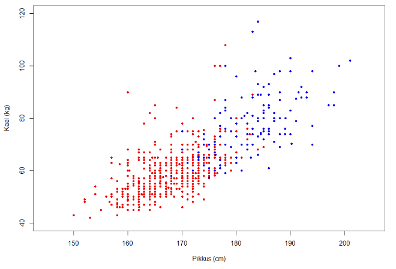

Nagu näha, siis eristuvad mehed ja naised üsna hästi kaalu ja pikkus järgi. Aga oletame, et me ei tea sugu ja proovime statistiliste meetodite abil hinnata, kas õnnestub antud andmestik jagada kaheks.

K-keskmiste klasterdamise puhul on eesmärk jagada objektid *k* klastrisse nii, et iga objekt kuuluks klastrisse mille keskpunkt on talle kõige lähedam. Antud juhul *k* = 2 ja nagu näha, siis õnnestus objektide gruppeerimine üsna sarnaselt sellele, mida indikeerib sugu.

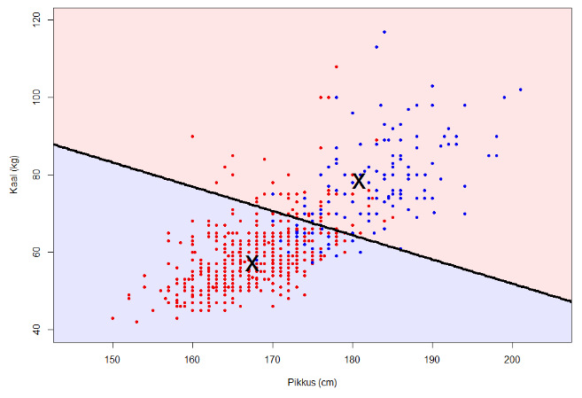

Suuruse *k* saame ise määrata, näitek *k* = 3 puhul oleks tulemus järgmine:

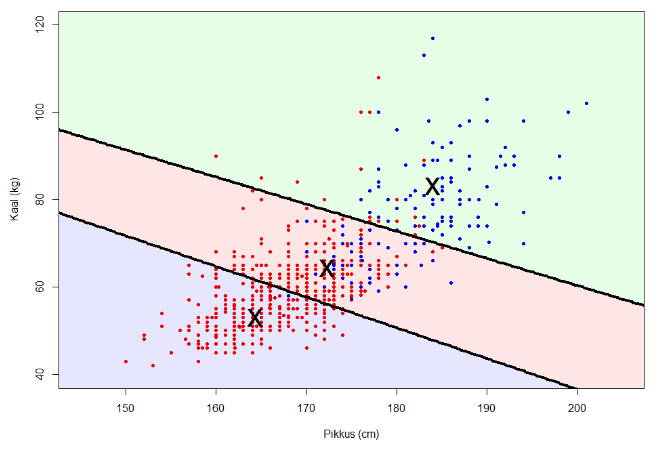

Kui me ei tea gruppide arvu andmestikus, siis on võimalik määrata optimaalne gruppide arv *k*. Esmalt aga mõned ettevalmistused.

## k-keskmiste klasterdamise ettevalmistused

Tunnused `kaive`, `tehinguid` ja `kesk_ost` on üsna eriskummaliste jaotustega. Neil kõigil on väga palju vaatlusi väikeste väärtustega ja “raskete sabadega” ehk mõned üksikud esktreemsed väärtused. Veendu selles eelnevalt räägitud raporti abil või jooksuta nt:

```r
hist(kliendid$kaive)
```

Kuna keskmised on tugevalt mõjutatud ekstreemsete väärtuste poolt, siis tuleb nende mõju vähendada. Selleks on erinevaid andmete transformeerimisviise - nt logaritmimine.

Võrdle näiteks järgmisi jooniseid:

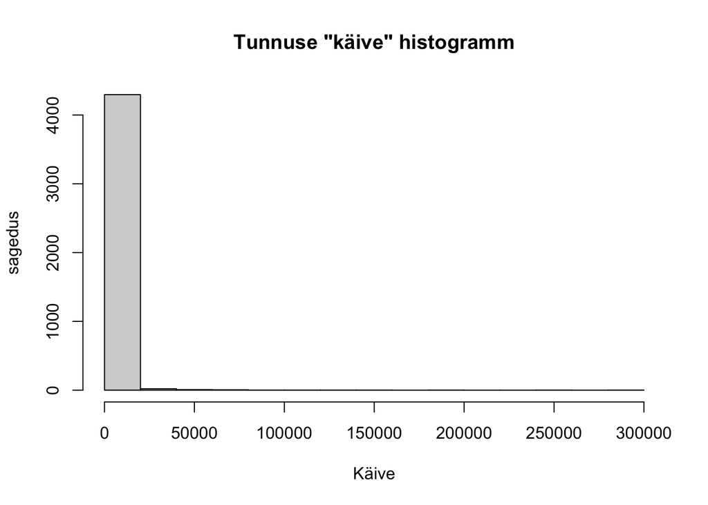

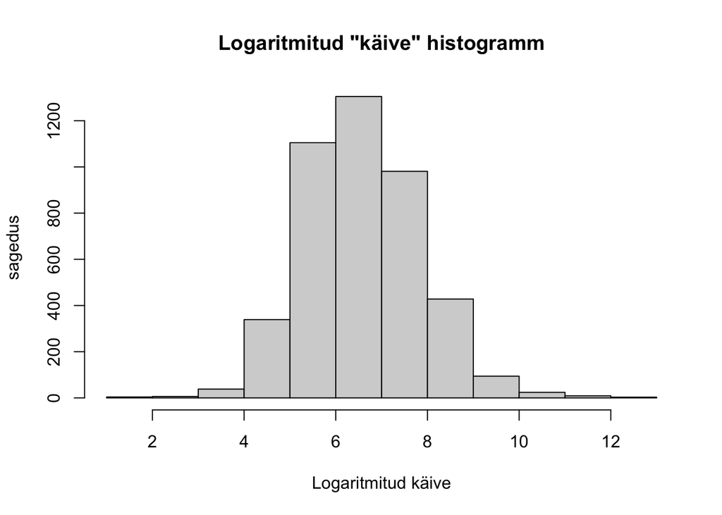

Logaritm säilitab väärtuste järekorra ja hiljem kui on vaja tõlgendada, siis saame kasutada pöördfunktsiooni ehk eksponenti `exp()`.

Ühtlasi töötab *k*-keskmiste klasterdamine standardiseeritud (keskmine = 0 ja sd = 1) andmetega paremini. Seda saame teha käsuga `scale()`. Kohe kindlasti tuleb standardiseerida andmestikku kui tunnused on erinevate skaaladega (nt “pikkus sentimeetrites” skaala VS “laste arv perekonnas” skaala).

Kogu eelneva saame tehtud järgmiste käskudega:

```r
# Skaleerime andmed
kliendid <- kliendid %>%
  mutate(log_kaive = log(kaive),
         log_tehinguid = log(tehinguid),
         log_kesk_ost = log(kesk_ost))

skaleeritud <- kliendid %>%
  select(log_kaive, log_tehinguid, log_kesk_ost) %>%
  scale()
```

## Klastrite arvu *k* määramine

Kuna antud meetod tahab, et me annaksime klastrite arvu ette, siis kuidas teha seda andmetest lähtuvalt?

Selleks saame kasutada “küünarnuki” meetodit (*elbow method*). Nimi on kentsakas aga tuleneb alloleva joonise kujust. Siin määratakse mitme klastriga toimub veel nö arvestatav “muutus” ehk millise klastrite arvu juures on klastrite keskpunktid üksteisest veel piisavalt kauged, et need eristaksid gruppe. Arvestatava “muutuse” määramine on tunnetuslik aga alloleval joonisel ütleks, et vasakult poolt pärast 4-ndat täppi suuremat langust enam ei toimu.

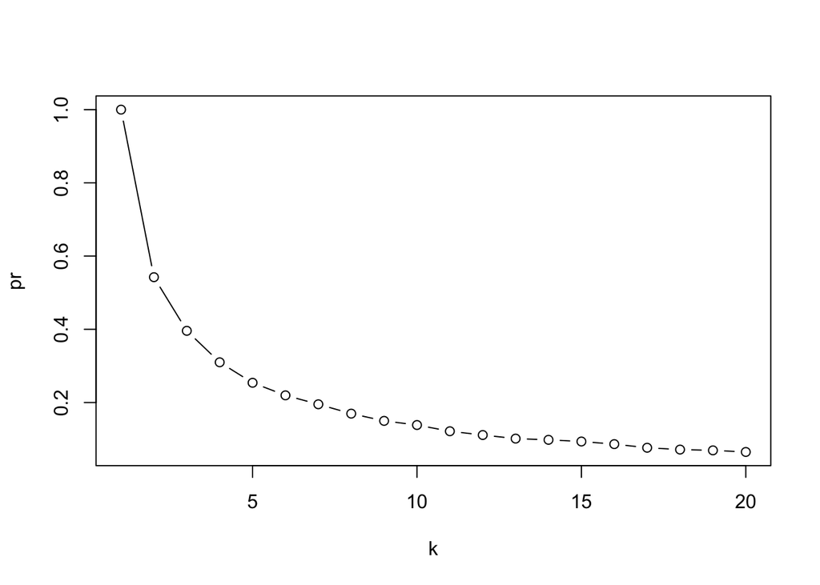

```r
# Eelnevad suurused, mis on vaja defineerida
k = 1:20
pr = 1

# Proovime läbi kõik klasterdamised klastriarvuga 1st-20ni.
for (i in 2:20){
  km = kmeans(skaleeritud,i)
  pr[i] = km$tot.withinss/km$totss
}

# Küünarnuki joonis
plot(k,pr,type="b")
```

## Klientide segmenteerimine

Olles teinud ära kogu eeltöö saame lõpuks leida klientide grupid. Funktsioon ise aga klastreid ei nimeta ega analüüsi, seega milliseid iseloomustavaid nimesid annaksid klastritele alloleva joonise järgi?

```r
# Klasterdamer ja leiame klastrite keskmised (ehk keskpunkti)
klastrid = kmeans(skaleeritud, 4)
klastrid$centers
```

```
##    log_kaive log_tehinguid log_kesk_ost
## 1  0.3864005     0.6345284   -0.1157885
## 2 -0.1729474    -0.7399513    0.6064076
## 3  1.5759706     1.4486599    0.9135451
## 4 -1.1333567    -0.7171307   -1.0518828
```

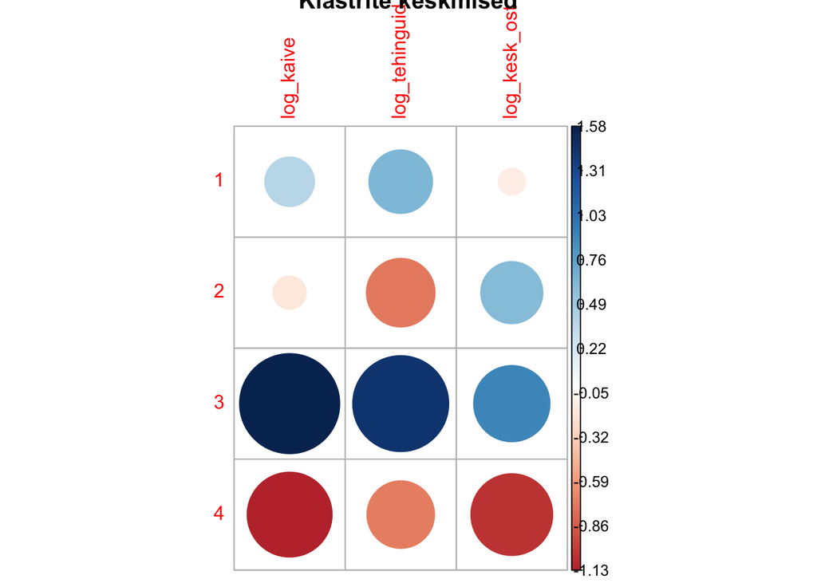

```r
# Joonis, mis hõlbustab analüüsimist
corrplot(klastrid$centers, is.corr=F, main = 'Klastrite keskmised')
```

Võime veenduda oma tõlgendustes järgmiste abistavate jooniste abil:

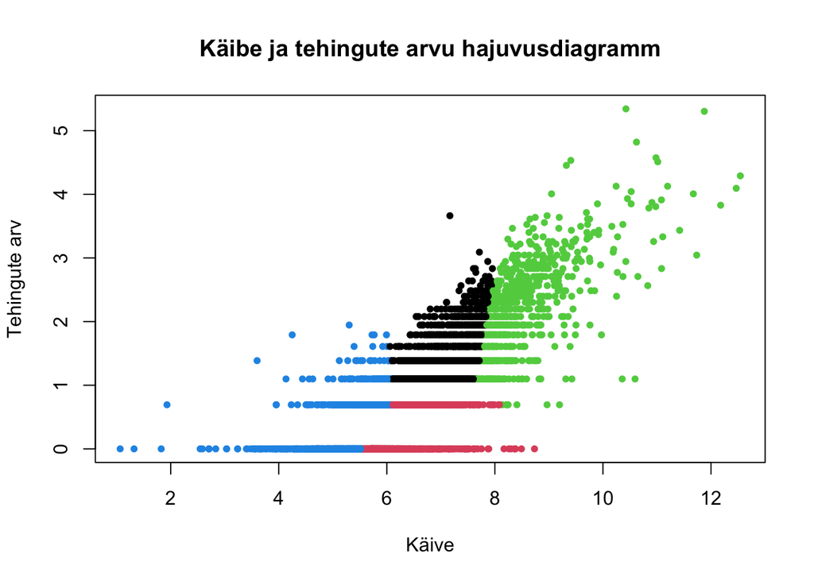

```r
plot(kliendid$log_kaive, kliendid$log_tehinguid, col = klastrid$cluster, pch = 20,
     xlab = 'Käive',
     ylab = 'Tehingute arv',
     main = 'Käibe ja tehingute arvu hajuvusdiagramm')
```

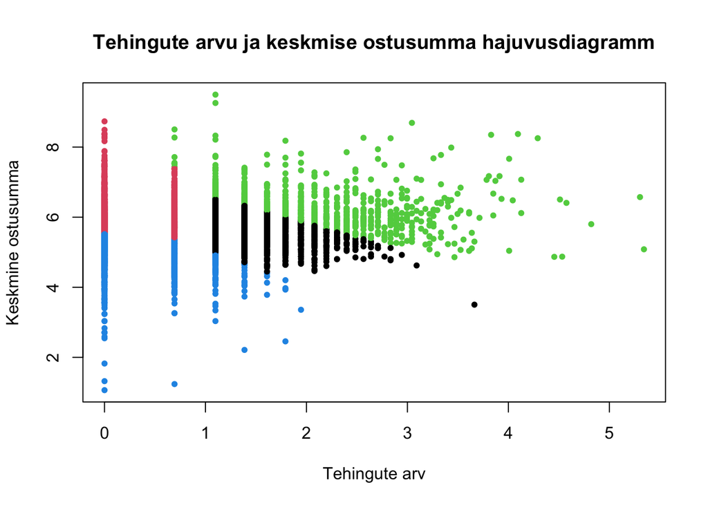

```r
plot(kliendid$log_tehinguid, kliendid$log_kesk_ost, col = klastrid$cluster, pch = 20,
     xlab = 'Tehingute arv',
     ylab = 'Keskmine ostusumma',
     main = 'Tehingute arvu ja keskmise ostusumma hajuvusdiagramm')
```

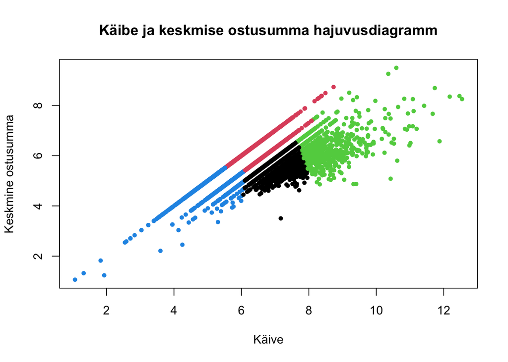

```r
plot(kliendid$log_kaive, kliendid$log_kesk_ost, col = klastrid$cluster, pch = 20,
     xlab = 'Käive',
     ylab = 'Keskmine ostusumma',
     main = 'Käibe ja keskmise ostusumma hajuvusdiagramm')
```

### Ülesanne nuputamiseks

*Eelmiseid jooniseid on kohmakas vaadata, sest saame jooniseid teha vaid kahe tunnuse kaupa. Rakenda eelmisel õppepäeval õpitud multidimensionaalset skaleerimist.*

## Klastrite eraldamine

Kui nüüd soovime teada millised kliendid kuuluvad teatud klastrisse (et siis vastavalt adresseerida või nt turundust suunata nendele), siis saame klientide ID-d eraldada järgmiste käskude abil:

```r
kliendid$kliendi_id[klastrid$cluster == 1] # 1. klastrisse kuuluvad kliendid
kliendid$kliendi_id[klastrid$cluster == 2] # 2. klastrisse kuuluvad kliendid
kliendid$kliendi_id[klastrid$cluster == 3] # 3. klastrisse kuuluvad kliendid
kliendid$kliendi_id[klastrid$cluster == 4] # 4. klastrisse kuuluvad kliendid
```